# Homework 02

## Question 1: Training and test error under a fixed design

Consider a linear regression problem with $n=100$ observations and $p=20$ available covariates. Generate one matrix $\mathbf X_{\mathrm{all}}\in\mathbb R^{n\times p}$ whose entries are independent $\mathcal N(0,1)$ random variables, and then keep this realized matrix fixed. Let

$$\beta_j=0.4^{\sqrt{j}},
\qquad j=1,\ldots,p,$$

and define

$$\boldsymbol\mu=\mathbf X_{\mathrm{all}}\boldsymbol\beta.$$

Generate one training response and one independent test response from

$$\begin{aligned}
\mathbf y
&=\boldsymbol\mu+\boldsymbol\epsilon,\\
\mathbf y^*
&=\boldsymbol\mu+\boldsymbol\epsilon^*,
\end{aligned}$$

where

$$\boldsymbol\epsilon,\boldsymbol\epsilon^*
\overset{\mathrm{ind}}{\sim}
\mathcal N_n(\mathbf 0,\mathbf I_n).$$

Here $\mathbf I_n$ is the $n\times n$ identity matrix.

For $m=0,1,\ldots,p$, fit a linear model with an intercept and the first $m$ columns of $\mathbf X_{\mathrm{all}}$ using $\mathbf y$. If $\widehat{\mathbf y}_m$ is its fitted mean vector, define

$$\operatorname{MSE}_{\mathrm{train},m}
=\frac{1}{n}
\left\lVert
\mathbf y-\widehat{\mathbf y}_m
\right\rVert_2^2,$$

and

$$\operatorname{MSE}_{\mathrm{test},m}
=\frac{1}{n}
\left\lVert
\mathbf y^*-\widehat{\mathbf y}_m
\right\rVert_2^2.$$

Repeat this process independently 200 times, keeping $\mathbf X_{\mathrm{all}}$ fixed.

Use seed `43202` before generating $\mathbf X_{\mathrm{all}}$ and the response errors. R and Python use different random-number generators, so their exact numerical values need not agree.

1. For each $m$, calculate the average training and test MSE over the 200 simulation runs. Plot both curves against $m$. Verify numerically that training MSE does not increase as predictors are added in each simulation run.

**Show the starter code**

```r
set.seed(43202)
n <- 100
p <- 20
X_all <- matrix(rnorm(n * p), n, p)
beta <- 0.4^sqrt(1:p)
mu <- X_all %*% beta
```

**Show the starter code**

```r
n_sim <- 200
train_mse <- matrix(NA, nrow = n_sim, ncol = p + 1)
test_mse <- matrix(NA, nrow = n_sim, ncol = p + 1)
```

**Show the starter code**

```r
for (s in 1:n_sim) {
  eps <- rnorm(n)
  eps_star <- rnorm(n)

  y <- mu + eps
  y_star <- mu + eps_star

  for (m in 0:p) {
    if (m == 0) {
      y_hat <- rep(mean(y), n)   # intercept-only model
    } else {
      Xm <- X_all[, 1:m, drop = FALSE]
      fit <- lm(y ~ Xm)
      y_hat <- fitted(fit)
    }
    train_mse[s, m + 1] <- mean((y - y_hat)^2)
    test_mse[s, m + 1]  <- mean((y_star - y_hat)^2)
  }
}
```

**Show the starter code**

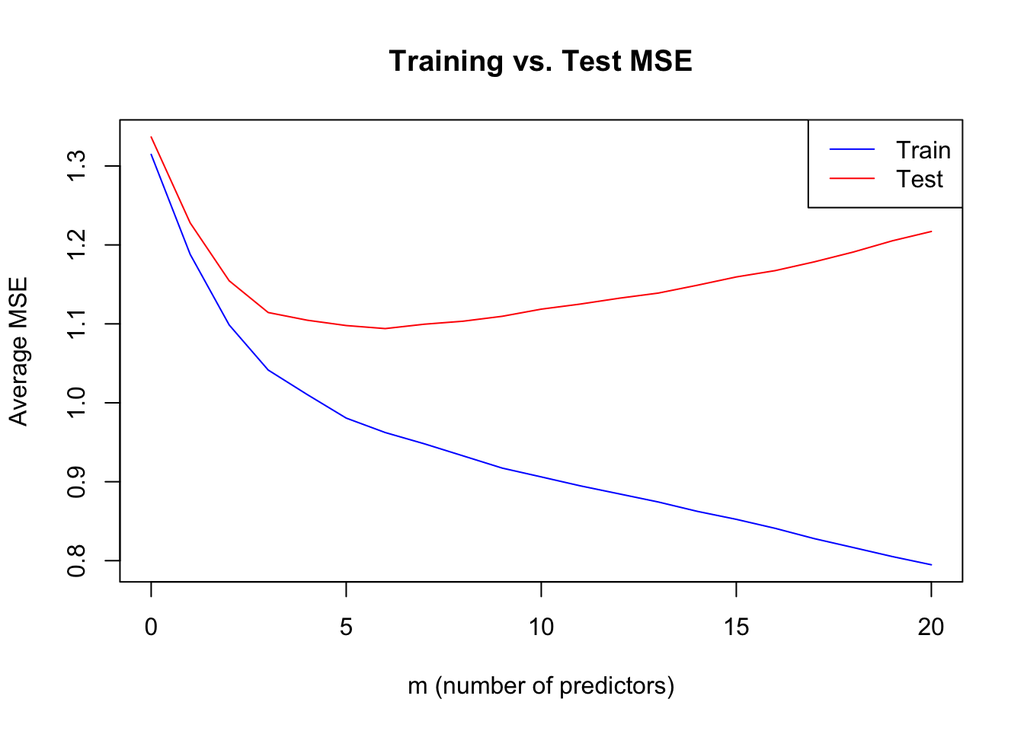

```r
avg_train_mse <- colMeans(train_mse)
avg_test_mse  <- colMeans(test_mse)

plot(0:p, avg_train_mse, type = "l", col = "blue",
     ylim = range(c(avg_train_mse, avg_test_mse)),
     xlab = "m (number of predictors)", ylab = "Average MSE",
     main = "Training vs. Test MSE")
lines(0:p, avg_test_mse, col = "red")
legend("topright", legend = c("Train", "Test"), col = c("blue", "red"), lty = 1)
```

2. For the model containing the first $m$ predictors, write

$$\mathbf X_m
=
[\mathbf 1,\mathbf x_1,\ldots,\mathbf x_m],
\qquad
\mathbf H_m
=
\mathbf X_m
(\mathbf X_m^{\mathsf T}\mathbf X_m)^{-1}
\mathbf X_m^{\mathsf T}.$$

Here $\mathbf X_m\in\mathbb R^{n\times(m+1)}$ and $\mathbf H_m\in\mathbb R^{n\times n}$. The model has $m+1$ fitted coefficients, including the intercept. Define its **total squared approximation bias** as

$$B_m^2
=\left\lVert
(\mathbf I_n-\mathbf H_m)\boldsymbol\mu
\right\rVert_2^2.$$

Thus, $B_m^2/n$ is the mean squared approximation bias.

Calculate the two theoretical expectations

$$E\!\left(
\operatorname{MSE}_{\mathrm{train},m}
\mid \mathbf X_{\mathrm{all}}
\right)
=\frac{B_m^2}{n}+1-\frac{m+1}{n},$$

and

$$E\!\left(
\operatorname{MSE}_{\mathrm{test},m}
\mid \mathbf X_{\mathrm{all}}
\right)
=\frac{B_m^2}{n}+1+\frac{m+1}{n}.$$

Add these expectations to your plot and compare them with the simulation averages.

**Show the starter code**

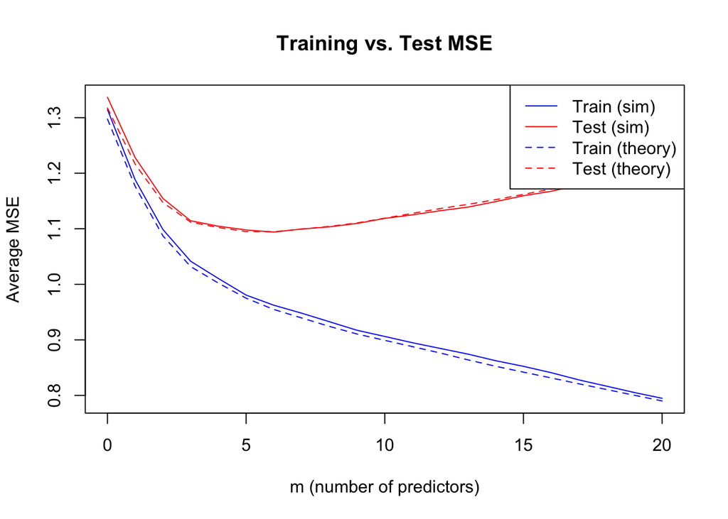

```r
Bm2 <- numeric(p + 1)  # storage, index m+1 as before

for (m in 0:p) {
  if (m == 0) {
    Hm <- matrix(1/n, nrow = n, ncol = n)  # hat matrix for intercept-only model
  } else {
    Xm <- cbind(1, X_all[, 1:m, drop = FALSE])
    Hm <- Xm %*% solve(t(Xm) %*% Xm) %*% t(Xm)
  }
  resid_vec <- (diag(n) - Hm) %*% mu
  Bm2[m + 1] <- sum(resid_vec^2)
}

theory_train <- Bm2 / n + 1 - (0:p + 1) / n
theory_test  <- Bm2 / n + 1 + (0:p + 1) / n

plot(0:p, avg_train_mse, type = "l", col = "blue",
     ylim = range(c(avg_train_mse, avg_test_mse, theory_train, theory_test)),
     xlab = "m (number of predictors)", ylab = "Average MSE",
     main = "Training vs. Test MSE")
theory_train <- Bm2 / n + 1 - (0:p + 1) / n
theory_test  <- Bm2 / n + 1 + (0:p + 1) / n

plot(0:p, avg_train_mse, type = "l", col = "blue",
     ylim = range(c(avg_train_mse, avg_test_mse, theory_train, theory_test)),
     xlab = "m (number of predictors)", ylab = "Average MSE",
     main = "Training vs. Test MSE")
lines(0:p, avg_test_mse, col = "red")
lines(0:p, theory_train, col = "blue", lty = 2)
lines(0:p, theory_test, col = "red", lty = 2)
legend("topright",
       legend = c("Train (sim)", "Test (sim)", "Train (theory)", "Test (theory)"),
       col = c("blue", "red", "blue", "red"),
       lty = c(1, 1, 2, 2))
```

3. Add the test MSE curve from one simulation run to the plot. Explain why this single curve is less smooth than the average test MSE. Use the approximation-bias and estimation-variance terms in the expected test MSE to explain why training MSE cannot be used by itself to select the predictor count.

**Show the starter code**

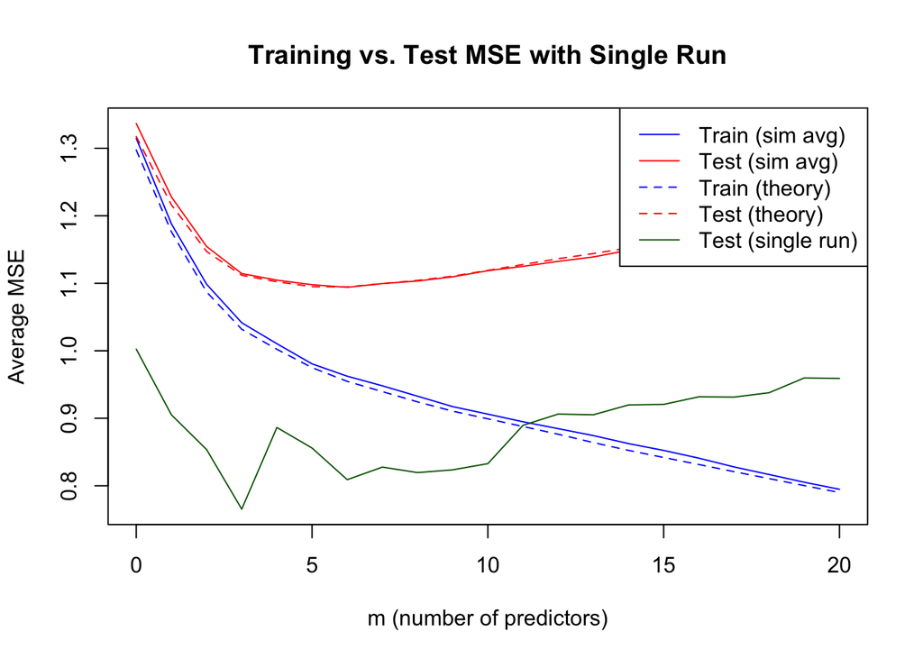

```r
plot(0:p, avg_train_mse, type = "l", col = "blue",
     ylim = range(c(avg_train_mse, avg_test_mse, theory_train, theory_test, test_mse[1, ])),
     xlab = "m (number of predictors)", ylab = "Average MSE",
     main = "Training vs. Test MSE with Single Run")
lines(0:p, avg_test_mse, col = "red")
lines(0:p, theory_train, col = "blue", lty = 2)
lines(0:p, theory_test, col = "red", lty = 2)
lines(0:p, test_mse[1, ], col = "darkgreen", lty = 1, lwd = 1)
legend("topright",
       legend = c("Train (sim avg)", "Test (sim avg)", "Train (theory)", "Test (theory)", "Test (single run)"),
       col = c("blue", "red", "blue", "red", "darkgreen"),
       lty = c(1, 1, 2, 2, 1))
```

## Question 2: Prediction error at one target point

Let $n=100$, $p=6$, and $\sigma^2=1$. Construct the fixed covariate matrix $\mathbf X_{\mathrm{all}}\in\mathbb R^{n\times p}$ with entries

$$(\mathbf X_{\mathrm{all}})_{ij}
=\sqrt{2}\cos\left\{
\frac{\pi j(i-\tfrac12)}{n}
\right\},
\qquad
i=1,\ldots,n,
\quad
j=1,\ldots,p.$$

Its columns satisfy

$$\mathbf 1^{\mathsf T}\mathbf X_{\mathrm{all}}=\mathbf 0^{\mathsf T},
\qquad
\frac{1}{n}\mathbf X_{\mathrm{all}}^{\mathsf T}\mathbf X_{\mathrm{all}}=\mathbf I_p.$$

Here $\mathbf I_p$ is the $p\times p$ identity matrix.

The following code shows a direct construction of $\mathbf X_{\mathrm{all}}$.

**R**

**Show the starter code**

```r
n <- 100
p <- 6
X_all <- outer(
  1:n, 1:p,
  function(i, j) sqrt(2) * cos(pi * j * (i - 0.5) / n)
)
```

**Python**

**Show the starter code**

```python
import numpy as np

n, p = 100, 6
i = np.arange(1, n + 1)[:, None]
j = np.arange(1, p + 1)[None, :]
X_all = np.sqrt(2) * np.cos(np.pi * j * (i - 0.5) / n)
```

Keep $\mathbf X_{\mathrm{all}}$ fixed and generate one training response from

$$\mathbf y
=\mathbf X_{\mathrm{all}}\boldsymbol\beta+\boldsymbol\epsilon,
\qquad
\boldsymbol\beta
=(0.5,0.5,0.5,0.5,0.5,0.5)^{\mathsf T},$$

where

$$\boldsymbol\epsilon
\sim
\mathcal N_n(\mathbf 0,\mathbf I_n).$$

Here $\mathbf I_n$ is the $n\times n$ identity matrix.

For $m=0,\ldots,p$, fit a linear model with an intercept and the first $m$ predictors. Consider prediction of the mean response at

$$\mathbf x_0=(0,1,0,0,1,0)^{\mathsf T}.$$

Write

$$\mu_0=\mathbf x_0^{\mathsf T}\boldsymbol\beta,$$

and let $\widehat\mu_{0,m}$ be the prediction from the model containing the first $m$ predictors. Here $x_{0j}$ denotes the $j$th coordinate of $\mathbf x_0$. For this design,

$$E\!\left[
\left(\widehat\mu_{0,m}-\mu_0\right)^2
\mid \mathbf X_{\mathrm{all}}
\right]
=
\left(
\sum_{j=m+1}^{p}x_{0j}\beta_j
\right)^2
+\frac{\sigma^2}{n}
\left(
1+\sum_{j=1}^{m}x_{0j}^2
\right).$$

1. Calculate $\mu_0$, the theoretical squared bias, and the expected squared error for $m=0,\ldots,p$ using the formula above. **You do not need to derive the formula.** Briefly explain in words why it consists of a squared bias term from omitted predictors and a variance term from estimating coefficients; no proof is required. Identify the values of $m$ where the expected squared error changes and where it remains unchanged.

**Show the starter code**

```r
beta <- rep(0.5, 6)
x0 <- c(0, 1, 0, 0, 1, 0)
sigma2 <- 1
n <- 100
p <- 6

mu0 <- sum(x0 * beta)
mu0
```

```
[1] 1
```

**Show the starter code**

```r
bias2 <- numeric(p + 1)
var_term <- numeric(p + 1)
expected_sq_error <- numeric(p + 1)

for (m in 0:p) {
  if (m < p) {
    omitted <- (m + 1):p
    bias_val <- sum(x0[omitted] * beta[omitted])
  } else {
    bias_val <- 0  # nothing omitted when m = p
  }
  bias2[m + 1] <- bias_val^2

  if (m == 0) {
    included_sq <- 0
  } else {
    included_sq <- sum(x0[1:m]^2)
  }
  var_term[m + 1] <- (sigma2 / n) * (1 + included_sq)

  expected_sq_error[m + 1] <- bias2[m + 1] + var_term[m + 1]
}

data.frame(m = 0:p, bias2 = bias2, var_term = var_term, expected_sq_error = expected_sq_error)
```

```
  m bias2 var_term expected_sq_error
1 0  1.00     0.01              1.01
2 1  1.00     0.01              1.01
3 2  0.25     0.02              0.27
4 3  0.25     0.02              0.27
5 4  0.25     0.02              0.27
6 5  0.00     0.03              0.03
7 6  0.00     0.03              0.03
```

2. Use seed `43203`. Generate the response, fit the models, and calculate

$$\left(\widehat\mu_{0,m}-\mu_0\right)^2.$$

Repeat this independently 200 times. Plot the simulation averages and theoretical expectations together. Report the smallest $m$ that minimizes the theoretical error.

**Show the starter code**

```r
n <- 100
p <- 6

X_all <- outer(
  1:n, 1:p,
  function(i, j) sqrt(2) * cos(pi * j * (i - 0.5) / n)
)

beta <- rep(0.5, 6)
x0 <- c(0, 1, 0, 0, 1, 0)
mu0 <- sum(x0 * beta)
```

**Show the starter code**

```r
set.seed(43203)

n_sim <- 200
sq_error <- matrix(NA, nrow = n_sim, ncol = p + 1)

for (s in 1:n_sim) {
  eps <- rnorm(n)
  y <- X_all %*% beta + eps

  for (m in 0:p) {
    if (m == 0) {
      mu0_hat <- mean(y)
    } else {
      Xm <- X_all[, 1:m, drop = FALSE]
      fit <- lm(y ~ Xm)
      coefs <- coef(fit)
      mu0_hat <- coefs[1] + sum(x0[1:m] * coefs[-1])
    }
    sq_error[s, m + 1] <- (mu0_hat - mu0)^2
  }
}
```

**Show the starter code**

```r
sim_avg_sq_error <- colMeans(sq_error)

# reuse expected_sq_error from part (a)
comparison <- data.frame(
  m = 0:p,
  simulation_avg = sim_avg_sq_error,
  theoretical = expected_sq_error
)
comparison
```

```
  m simulation_avg theoretical
1 0     1.01891864        1.01
2 1     1.01891864        1.01
3 2     0.26711699        0.27
4 3     0.26711699        0.27
5 4     0.26711699        0.27
6 5     0.03375873        0.03
7 6     0.03375873        0.03
```

**Show the starter code**

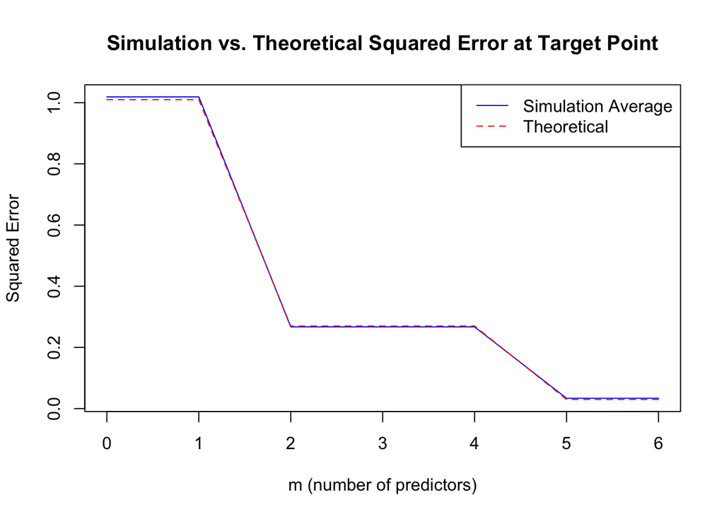

```r
plot(0:p, sim_avg_sq_error, type = "l", col = "blue",
     ylim = range(c(sim_avg_sq_error, expected_sq_error)),
     xlab = "m (number of predictors)", ylab = "Squared Error",
     main = "Simulation vs. Theoretical Squared Error at Target Point")
lines(0:p, expected_sq_error, col = "red", lty = 2)
legend("topright",
       legend = c("Simulation Average", "Theoretical"),
       col = c("blue", "red"),
       lty = c(1, 2))
```

**Show the starter code**

```r
which.min(expected_sq_error) - 1  # subtract 1 since index 1 corresponds to m=0
```

```
[1] 5
```

3. All six regression coefficients are nonzero. Explain why only predictors 2 and 5 contribute directly to the mean response at $\mathbf x_0$. Contrast this target-specific error with the test MSE averaged over all rows of $\mathbf X_{\mathrm{all}}$ in Question 1.

**Show the starter code**

```r
## Only predictors 2 and 5 matter here because the prediction at x0 is μ₀ = Σⱼ x0_j·βⱼ, and even though every βⱼ = 0.5 is nonzero, x0 = (0,1,0,0,1,0) is zero everywhere except positions 2 and 5 — so any term where x0_j = 0 simply vanishes from the sum, regardless of how large that predictor's true effect is elsewhere; predictors 1, 3, 4, and 6 have real coefficients but happen to be irrelevant to this specific point. This contrasts with Question 1's test MSE, which averages squared error across all 100 rows of X_all — a global measure where most predictors end up mattering to some observations, since it's unlikely every row shares x0's pattern of zeros. Question 2's error is inherently local: a predictor's importance isn't a fixed global property, but can depend entirely on which specific input you're predicting at, so a model's overall average performance (Question 1) and its performance at one particular target point (Question 2) can diverge substantially.
```

## Question 3: The optimism correction

Choose one candidate model before observing the response. Let $p$ be its number of predictors and let $\mathbf X\in\mathbb R^{n\times(p+1)}$ be its full-rank design matrix, including the intercept. The model has $p+1$ fitted coefficients. Let

$$\mathbf H
=\mathbf X
(\mathbf X^{\mathsf T}\mathbf X)^{-1}
\mathbf X^{\mathsf T}$$

be its hat matrix. Suppose

$$\mathbf y=\boldsymbol\mu+\boldsymbol\epsilon,
\qquad
\mathbf y^*=\boldsymbol\mu+\boldsymbol\epsilon^*,$$

Conditional on the fixed design $\mathbf X$, the two error vectors are independent, have mean zero, and have covariance matrix $\sigma^2\mathbf I_n$. Define

$$\operatorname{MSE}_{\mathrm{train}}
=
\frac{1}{n}
\left\lVert
\mathbf y-\mathbf H\mathbf y
\right\rVert_2^2,
\qquad
\operatorname{MSE}_{\mathrm{test}}
=
\frac{1}{n}
\left\lVert
\mathbf y^*-\mathbf H\mathbf y
\right\rVert_2^2.$$

The conditional bias vector of the fitted mean is

$$E(\mathbf H\mathbf y\mid\mathbf X)-\boldsymbol\mu
=
-(\mathbf I_n-\mathbf H)\boldsymbol\mu.$$

Let $B^2$ denote the **total squared approximation bias**:

$$B^2
=\left\lVert
(\mathbf I_n-\mathbf H)\boldsymbol\mu
\right\rVert_2^2.$$

Thus, $B^2/n$ is the mean squared approximation bias.

You may use

$$\mathbf H^{\mathsf T}=\mathbf H,
\qquad
\mathbf H^2=\mathbf H,
\qquad
\operatorname{tr}(\mathbf H)=p+1.$$

For any fixed matrix $\mathbf A$, you may also use

$$E\!\left(
\boldsymbol\epsilon^{\mathsf T}
\mathbf A
\boldsymbol\epsilon
\mid \mathbf X
\right)
=\sigma^2\operatorname{tr}(\mathbf A).$$

1. Derive

$$E(\operatorname{MSE}_{\mathrm{train}}\mid\mathbf X)
=\frac{B^2}{n}
+\sigma^2\left(1-\frac{p+1}{n}\right),$$

and

and

$$E(\text{MSE}_{\text{test}}\mid\mathbf X)
=\frac{B^2}{n}
+\sigma^2\left(1+\frac{p+1}{n}\right).$$

We derive the two expectations by substituting $\mathbf y=\boldsymbol\mu+\boldsymbol\epsilon$ (and $\mathbf y^*=\boldsymbol\mu+\boldsymbol\epsilon^*$) into the definitions of training and test MSE.

**Training MSE.** Since $\mathbf H\mathbf y = \mathbf H\boldsymbol\mu+\mathbf H\boldsymbol\epsilon$,

$$\mathbf y-\mathbf H\mathbf y = (\mathbf I-\mathbf H)\boldsymbol\mu + (\mathbf I-\mathbf H)\boldsymbol\epsilon.$$

Using $(\mathbf I-\mathbf H)^{\mathsf T}(\mathbf I-\mathbf H)=(\mathbf I-\mathbf H)^2=\mathbf I-\mathbf H$ (since $\mathbf H$ is symmetric and idempotent), expanding the squared norm gives

$$n\cdot\text{MSE}_{\text{train}} = \lVert(\mathbf I-\mathbf H)\boldsymbol\mu\rVert^2 + 2\boldsymbol\epsilon^{\mathsf T}(\mathbf I-\mathbf H)\boldsymbol\mu + \boldsymbol\epsilon^{\mathsf T}(\mathbf I-\mathbf H)\boldsymbol\epsilon.$$

Taking expectations conditional on $\mathbf X$: the first term equals $B^2$ exactly; the middle term vanishes since $E(\boldsymbol\epsilon\mid\mathbf X)=\mathbf 0$; and the last term equals $\sigma^2\operatorname{tr}(\mathbf I-\mathbf H)=\sigma^2(n-(p+1))$ by the given trace identity. Thus

$$E(n\cdot\text{MSE}_{\text{train}}\mid\mathbf X) = B^2+\sigma^2(n-(p+1)),$$

and dividing by $n$,

$$E(\text{MSE}_{\text{train}}\mid\mathbf X) = \frac{B^2}{n}+\sigma^2\left(1-\frac{p+1}{n}\right).$$

**Test MSE.** Since $\mathbf y^*-\mathbf H\mathbf y = (\mathbf I-\mathbf H)\boldsymbol\mu+\boldsymbol\epsilon^*-\mathbf H\boldsymbol\epsilon$, expanding the squared norm produces the term $\lVert(\mathbf I-\mathbf H)\boldsymbol\mu\rVert^2=B^2$, plus $\lVert\boldsymbol\epsilon^*\rVert^2$ and $\lVert\mathbf H\boldsymbol\epsilon\rVert^2$, along with several cross-terms. Because $\boldsymbol\epsilon$ and $\boldsymbol\epsilon^*$ are independent with mean zero, and $(\mathbf I-\mathbf H)\boldsymbol\mu$ is a fixed vector, every cross-term has expectation zero. Using $E(\boldsymbol\epsilon^{*\mathsf T}\boldsymbol\epsilon^*\mid\mathbf X)=\sigma^2\operatorname{tr}(\mathbf I_n)=\sigma^2 n$ and $E(\boldsymbol\epsilon^{\mathsf T}\mathbf H^{\mathsf T}\mathbf H\boldsymbol\epsilon\mid\mathbf X)=E(\boldsymbol\epsilon^{\mathsf T}\mathbf H\boldsymbol\epsilon\mid\mathbf X)=\sigma^2\operatorname{tr}(\mathbf H)=\sigma^2(p+1)$,

$$E(n\cdot\text{MSE}_{\text{test}}\mid\mathbf X) = B^2+\sigma^2 n+\sigma^2(p+1),$$

so

$$E(\text{MSE}_{\text{test}}\mid\mathbf X) = \frac{B^2}{n}+\sigma^2\left(1+\frac{p+1}{n}\right).$$

**Intuition.** The training-MSE variance term is *subtracted* because the fitted values $\mathbf H\mathbf y$ were built using the same noise $\boldsymbol\epsilon$ that appears in the residual, so some of that noise is absorbed into the fit itself and artificially shrinks the apparent error. The test-MSE variance term is *added* because the test noise $\boldsymbol\epsilon^*$ is independent of the fitted model, so there is no such cancellation — the model instead pays the full cost of both the new noise and its own estimation variance.

2. Deduce the expected optimism, defined as $E(\operatorname{MSE}_{\mathrm{test}}-\operatorname{MSE}_{\mathrm{train}}\mid\mathbf X)$. For

$$n=120,
\qquad
p=4,
\qquad
\frac{B^2}{n}=0.04,
\qquad
\sigma^2=1,$$

calculate the expected training MSE, expected test MSE, and their difference. Explain why the ordering need not hold for every realized pair of responses.

The expected optimism is

$$E(\text{MSE}_{\text{test}}-\text{MSE}_{\text{train}}\mid\mathbf X) = \sigma^2\left(1+\frac{p+1}{n}\right) - \sigma^2\left(1-\frac{p+1}{n}\right) = \frac{2\sigma^2(p+1)}{n}.$$

For $n=120$, $p=4$, $B^2/n=0.04$, and $\sigma^2=1$:

$$E(\text{MSE}_{\text{train}}\mid\mathbf X) = 0.04 + 1\left(1-\frac{5}{120}\right) = 0.9983,$$

$$E(\text{MSE}_{\text{test}}\mid\mathbf X) = 0.04 + 1\left(1+\frac{5}{120}\right) = 1.0817,$$

$$E(\text{MSE}_{\text{test}}-\text{MSE}_{\text{train}}\mid\mathbf X) = \frac{2(5)}{120} = 0.0833.$$

These are expectations, describing the average behavior across infinitely many hypothetical realizations of $\boldsymbol\epsilon$ and $\boldsymbol\epsilon^*$. For any single realized pair of responses, $\text{MSE}_{\text{train}}$ and $\text{MSE}_{\text{test}}$ are random variables with their own sampling variability, so it is entirely possible for a particular realized test MSE to fall below the realized training MSE just by chance. The inequality $E(\text{MSE}_{\text{test}}) > E(\text{MSE}_{\text{train}})$ holds only on average, not for every individual sample.

**Show the starter code**

```r
n <- 120
p <- 4
B2_over_n <- 0.04
sigma2 <- 1

E_train <- B2_over_n + sigma2 * (1 - (p+1)/n)
E_test  <- B2_over_n + sigma2 * (1 + (p+1)/n)
optimism <- E_test - E_train

E_train
```

```
[1] 0.9983333
```

**Show the starter code**

```r
E_test
```

```
[1] 1.081667
```

**Show the starter code**

```r
optimism
```

```
[1] 0.08333333
```

3. Continue with $n=120$ and $p=4$. Suppose the candidate model has residual sum of squares $\operatorname{RSS}=116.4$, and suppose a common estimate of the error variance is $\widehat\sigma^2=0.96$.

Calculate

$$\widehat{\operatorname{MSE}}_{\mathrm{test}}
=\frac{
\operatorname{RSS}+2(p+1)\widehat\sigma^2
}{n},$$

and

$$C_p
=\frac{\operatorname{RSS}}{\widehat\sigma^2}
-n+2(p+1).$$

Show how these two quantities are related, and explain why minimizing $C_p$ is equivalent to minimizing the corrected test MSE when $n$ and $\widehat\sigma^2$ are common to all candidate models.

$$\widehat{\text{MSE}}_{\text{test}} = \frac{\text{RSS}+2(p+1)\widehat\sigma^2}{n} = \frac{116.4+2(5)(0.96)}{120} = \frac{126}{120} = 1.05,$$

$$C_p = \frac{\text{RSS}}{\widehat\sigma^2}-n+2(p+1) = \frac{116.4}{0.96}-120+10 = 11.25.$$

These two quantities are related by

$$\widehat{\text{MSE}}_{\text{test}} = \frac{\widehat\sigma^2\left(C_p+n\right)}{n},$$

which can be verified directly: $\widehat\sigma^2(C_p+n)/n = 0.96(11.25+120)/120 = 1.05$, matching the value computed above.

Since $n$ and $\widehat\sigma^2$ are the same for every candidate model being compared, this relationship is a strictly increasing linear (affine) transformation of $C_p$ with positive slope $\widehat\sigma^2/n$ and intercept $\widehat\sigma^2$. A positive linear transformation preserves ordering, so whichever model minimizes $C_p$ also minimizes $\widehat{\text{MSE}}_{\text{test}}$, and vice versa — the two criteria are equivalent for model selection purposes whenever $n$ and $\widehat\sigma^2$ are held fixed across models.

**Show the starter code**

```r
RSS <- 116.4
sigma2_hat <- 0.96
n <- 120
p <- 4

MSE_test_hat <- (RSS + 2*(p+1)*sigma2_hat) / n
Cp <- RSS/sigma2_hat - n + 2*(p+1)

MSE_test_hat
```

```
[1] 1.05
```

**Show the starter code**

```r
Cp
```

```
[1] 11.25
```

**Show the starter code**

```r
# verify the relationship
sigma2_hat * (Cp + n) / n
```

```
[1] 1.05
```

## Question 4: Comparing Mallows’ $C_p$, AIC, and BIC

Use `data/diabetes.csv`, with `y` as the response. Use rows 1 through 370 as the training data, and let $n=370$ denote the training sample size. Do not use rows 371 through 442 in this question. Fit the following ordinary least-squares models, each with an intercept.

| Model | Predictors | $p$ |
| --- | --- | --- |
| Model A | `bmi`, `bp`, `s5`, `sex`, `s1`, `s2`, `s4` | 7 |
| Model B | all predictors in Model A, followed by `s6` | 8 |
| Full reference | all ten predictors | 10 |

Here $p$ counts predictors, so each model has $p+1$ fitted coefficients including the intercept. Estimate one common noise variance from the full reference model, using $p=10$:

$$\widehat\sigma^2
=\frac{\operatorname{RSS}_{\mathrm{full}}}{n-(p+1)}.$$

For Models A and B, calculate

$$C_p
=\frac{\operatorname{RSS}}{\widehat\sigma^2}
-n+2(p+1),$$

$$\operatorname{AIC}^{\mathrm{red}}
=n\log\left(\frac{\operatorname{RSS}}{n}\right)+2(p+1),$$

and

$$\operatorname{BIC}^{\mathrm{red}}
=n\log\left(\frac{\operatorname{RSS}}{n}\right)
+(p+1)\log(n).$$

The reduced AIC and BIC omit constants shared by the two candidate models. Smaller values are preferred within each criterion.

1. Fit the three models. Report $p$, RSS, the residual degrees of freedom of the full model, and $\widehat\sigma^2$.

**Show the starter code**

```r
library(dplyr)
```

**Show the starter code**

```r
diabetes <- read.csv("data/diabetes.csv")
train <- diabetes[1:370, ]
n <- 370

# Model A
fitA <- lm(y ~ bmi + bp + s5 + sex + s1 + s2 + s4, data = train)
RSS_A <- sum(residuals(fitA)^2)
p_A <- 7

# Model B
fitB <- lm(y ~ bmi + bp + s5 + sex + s1 + s2 + s4 + s6, data = train)
RSS_B <- sum(residuals(fitB)^2)
p_B <- 8

# Full reference model
fitFull <- lm(y ~ age + sex + bmi + bp + s1 + s2 + s3 + s4 + s5 + s6, data = train)
RSS_full <- sum(residuals(fitFull)^2)
p_full <- 10

df_full <- n - (p_full + 1)
sigma2_hat <- RSS_full / df_full

results_4a <- data.frame(
  model = c("Model A", "Model B", "Full"),
  p = c(p_A, p_B, p_full),
  RSS = c(RSS_A, RSS_B, RSS_full)
)

results_4a
```

```
    model  p     RSS
1 Model A  7 1098909
2 Model B  8 1089717
3    Full 10 1089452
```

**Show the starter code**

```r
df_full
```

```
[1] 359
```

**Show the starter code**

```r
sigma2_hat
```

```
[1] 3034.684
```

2. Calculate $C_p$, reduced AIC, and reduced BIC for Models A and B. State which model each criterion selects. Do not compare numerical values across different criteria.

**Show the starter code**

```r
compute_criteria <- function(RSS, p, n, sigma2_hat) {
  Cp <- RSS / sigma2_hat - n + 2 * (p + 1)
  AIC_red <- n * log(RSS / n) + 2 * (p + 1)
  BIC_red <- n * log(RSS / n) + (p + 1) * log(n)
  c(Cp = Cp, AIC_red = AIC_red, BIC_red = BIC_red)
}

crit_A <- compute_criteria(RSS_A, p_A, n, sigma2_hat)
crit_B <- compute_criteria(RSS_B, p_B, n, sigma2_hat)

criteria_table <- rbind(A = crit_A, B = crit_B)
criteria_table
```

```
        Cp  AIC_red  BIC_red
A 8.116253 2974.640 3005.948
B 7.087434 2973.532 3008.754
```

Comparing Models A and B: $C_p$ favors Model B (7.09 vs. 8.12), and reduced AIC also favors Model B (2973.53 vs. 2974.64), both by a small margin. Reduced BIC, however, favors Model A (3005.95 vs. 3008.75) — the only criterion of the three that prefers the more parsimonious model. These values are only meaningful within the same criterion (comparing A’s $C_p$ to B’s $C_p$); they should never be compared across different criteria, since $C_p$, AIC, and BIC are on different numerical scales.

3. Compare the improvement in fit from adding `s6` with the one-parameter penalty under each criterion. Use this comparison to explain any disagreement. Why does selecting a model not establish that it is the true data-generating model?

Adding `s6` to Model A reduces RSS from 1,098,909 to 1,089,717, a reduction of 9,192 — a small improvement relative to the residual sum of squares’ overall size. Each criterion weighs this improvement against a one-parameter penalty differently: $C_p$ and AIC both add a fixed penalty of $2$ per additional parameter, while BIC adds a penalty of $\log(n) = \log(370) \approx 5.91$ per additional parameter, roughly three times steeper. This difference in penalty size explains the disagreement observed above: the relatively small RSS improvement from adding `s6` is enough to outweigh the lighter $2$-point penalty used by $C_p$ and AIC, so both favor including `s6` (Model B), but it is not large enough to outweigh BIC’s much heavier $\log(n)$ penalty, so BIC favors excluding it (Model A).

Selecting a model with one of these criteria does not establish that it is the true data-generating model. These criteria only compare a fixed, finite set of candidate models against each other on a specific dataset — they identify which candidate best balances fit and complexity among the options considered, not whether any candidate correctly represents the actual underlying relationship. The true relationship between the predictors and the response may not even be linear, and important predictors may be missing entirely from every candidate considered; none of these criteria can detect either possibility.

## Question 5: Validation and final test data

Use rows 1 through 370 of `diabetes.csv` as the training data and rows 371 through 442 as the final test data. Consider eleven nested candidate models. For $m=0,1,\ldots,10$, the model with $m$ predictors contains an intercept and the first $m$ predictors in this order:

`age`, `sex`, `bmi`, `bp`, `s1`, `s2`, `s3`, `s4`, `s5`, `s6`.

An analyst proposes the following procedure:

1. Fit all eleven candidate models using the training data.
2. Calculate the MSE of each model on the final test data.
3. Select the model with the smallest test MSE.
4. Report that minimum as the final estimate of prediction error.

The analyst argues that the procedure is valid because the final test data were not used to estimate the regression coefficients.

1. Identify the first step that misuses the final test data. Explain why the minimum of eleven test MSE values is generally too favorable as an estimate of the selected procedure’s future prediction error.

The first step that misuses the final test data is step 2: calculating the test MSE of all eleven candidate models on the final test data, before a single model has been chosen. Even though the test data were not used to *estimate the regression coefficients*, they were used to *choose which model to report* — this is itself a form of fitting to the test data, just at the model-selection level rather than the coefficient-estimation level.

Because eleven different models are each evaluated on the same fixed test set, and the smallest of eleven MSE values is then selected, this minimum reflects two combined sources of “goodness”: how genuinely well that model predicts, and how much that particular test set happened to favor it by chance. With eleven candidates evaluated on one fixed sample, at least one is likely to look unusually good simply due to sampling variability in the test set, even if no single model is truly better than the others. Reporting the minimum of eleven values as the estimate of prediction error therefore selects for favorable noise as well as genuine model quality, making it optimistically biased — it systematically understates the prediction error the selected procedure would actually achieve on new data.

2. Rewrite the analysis using five-fold cross-validation within the training data. State how the predictor count is selected, what is refitted, and when the final test data may be used.

A corrected procedure uses five-fold cross-validation entirely within the training data (rows 1-370), holding the final test data (rows 371-442) completely untouched until the very end:

1. Split the training data into five folds.
2. For each of the eleven candidate predictor counts $m=0,\ldots,10$, cycle through the five folds: fit the model on four folds and compute its MSE on the held-out fifth fold. Average these five MSE values to get one cross-validated MSE estimate for that $m$.
3. Select the predictor count $m$ that gives the smallest average cross-validated MSE. This selection uses only the training data.
4. Refit the selected model (using the chosen $m$) one final time, using **all** of the training data (all 370 rows).
5. Only now may the final test data be used, exactly once, to evaluate this single, already-chosen model and report its test MSE as the honest estimate of prediction error.

The final test data is never touched during model selection — it is used only once, at the very end, to evaluate the one model that cross-validation already identified as best.

3. Suppose the analyst has already examined all eleven test MSE values. What can still be reported transparently, and what additional data would be needed for a new final evaluation?

Having already examined all eleven test MSE values, the analyst can still transparently report the full comparison across all eleven candidates — for example, presenting a table or plot showing how test MSE varies with predictor count — rather than reporting a single number as though it were a valid estimate of future prediction error. This is an honest description of what happened, not a claim about future performance.

However, no number derived from this same test set can be reported as an unbiased estimate of the selected model’s future prediction error, since the test data has already been used to compare models and would be contaminated by the same selection bias described in part (a). To obtain a valid final evaluation, an entirely new, previously unseen dataset (not used in either training or the original test comparison) would be needed to evaluate the eventually chosen model just once.

## Reference

James, Witten, Hastie, Tibshirani, and Taylor, [*An Introduction to Statistical Learning*](https://www.statlearning.com/), Chapters 3, 5, and 6.